# Risk Factor Analysis

## Outcome Variable

**Outcome Variable:** ever_stunted

## Predictor Variables

**Intervention Variable:** meducyrs

**Adjustment Set:**

- arm
- W_mage
- feducyrs
- W_mhtcm
- W_gagebrth
- W_birthwt
- W_birthlen
- single
- delta_W_mage
- delta_feducyrs
- delta_W_mhtcm
- delta_W_gagebrth
- delta_W_birthwt
- delta_W_birthlen
- delta_single

## Stratifying Variables

The analysis was stratified on these variable(s):

- agecat
- studyid
- country

## Data Summary

| agecat | studyid | country | meducyrs | ever_stunted | n_cell | n |
| --- | --- | --- | --- | --- | --- | --- |
| 0-6 months | ki0047075b-MAL-ED | BANGLADESH | Q4 | 0 | 57 | 214 |
| 0-6 months | ki0047075b-MAL-ED | BANGLADESH | Q4 | 1 | 4 | 214 |
| 0-6 months | ki0047075b-MAL-ED | BANGLADESH | Q1 | 0 | 29 | 214 |
| 0-6 months | ki0047075b-MAL-ED | BANGLADESH | Q1 | 1 | 13 | 214 |
| 0-6 months | ki0047075b-MAL-ED | BANGLADESH | Q2 | 0 | 23 | 214 |
| 0-6 months | ki0047075b-MAL-ED | BANGLADESH | Q2 | 1 | 5 | 214 |
| 0-6 months | ki0047075b-MAL-ED | BANGLADESH | Q3 | 0 | 68 | 214 |
| 0-6 months | ki0047075b-MAL-ED | BANGLADESH | Q3 | 1 | 15 | 214 |
| 0-6 months | ki0047075b-MAL-ED | BRAZIL | Q4 | 0 | 71 | 232 |
| 0-6 months | ki0047075b-MAL-ED | BRAZIL | Q4 | 1 | 8 | 232 |
| 0-6 months | ki0047075b-MAL-ED | BRAZIL | Q1 | 0 | 44 | 232 |
| 0-6 months | ki0047075b-MAL-ED | BRAZIL | Q1 | 1 | 3 | 232 |
| 0-6 months | ki0047075b-MAL-ED | BRAZIL | Q2 | 0 | 36 | 232 |
| 0-6 months | ki0047075b-MAL-ED | BRAZIL | Q2 | 1 | 8 | 232 |
| 0-6 months | ki0047075b-MAL-ED | BRAZIL | Q3 | 0 | 56 | 232 |
| 0-6 months | ki0047075b-MAL-ED | BRAZIL | Q3 | 1 | 6 | 232 |
| 0-6 months | ki0047075b-MAL-ED | INDIA | Q4 | 0 | 53 | 220 |
| 0-6 months | ki0047075b-MAL-ED | INDIA | Q4 | 1 | 10 | 220 |
| 0-6 months | ki0047075b-MAL-ED | INDIA | Q1 | 0 | 31 | 220 |
| 0-6 months | ki0047075b-MAL-ED | INDIA | Q1 | 1 | 4 | 220 |
| 0-6 months | ki0047075b-MAL-ED | INDIA | Q2 | 0 | 44 | 220 |
| 0-6 months | ki0047075b-MAL-ED | INDIA | Q2 | 1 | 8 | 220 |
| 0-6 months | ki0047075b-MAL-ED | INDIA | Q3 | 0 | 57 | 220 |
| 0-6 months | ki0047075b-MAL-ED | INDIA | Q3 | 1 | 13 | 220 |
| 0-6 months | ki0047075b-MAL-ED | NEPAL | Q4 | 0 | 16 | 225 |
| 0-6 months | ki0047075b-MAL-ED | NEPAL | Q4 | 1 | 4 | 225 |
| 0-6 months | ki0047075b-MAL-ED | NEPAL | Q1 | 0 | 28 | 225 |
| 0-6 months | ki0047075b-MAL-ED | NEPAL | Q1 | 1 | 2 | 225 |
| 0-6 months | ki0047075b-MAL-ED | NEPAL | Q2 | 0 | 55 | 225 |
| 0-6 months | ki0047075b-MAL-ED | NEPAL | Q2 | 1 | 11 | 225 |

[output cut: 588 more lines]

The following strata were considered:

- agecat: 0-24 months, studyid: ki0047075b-MAL-ED, country: BANGLADESH
- agecat: 0-24 months, studyid: ki0047075b-MAL-ED, country: BRAZIL
- agecat: 0-24 months, studyid: ki0047075b-MAL-ED, country: INDIA
- agecat: 0-24 months, studyid: ki0047075b-MAL-ED, country: NEPAL
- agecat: 0-24 months, studyid: ki0047075b-MAL-ED, country: PERU
- agecat: 0-24 months, studyid: ki0047075b-MAL-ED, country: SOUTH AFRICA
- agecat: 0-24 months, studyid: ki0047075b-MAL-ED, country: TANZANIA, UNITED REPUBLIC OF
- agecat: 0-24 months, studyid: ki1000108-CMC-V-BCS-2002, country: INDIA
- agecat: 0-24 months, studyid: ki1000108-IRC, country: INDIA
- agecat: 0-24 months, studyid: ki1000109-EE, country: PAKISTAN
- agecat: 0-24 months, studyid: ki1000304b-SAS-CompFeed, country: INDIA
- agecat: 0-24 months, studyid: ki1000304b-SAS-FoodSuppl, country: INDIA
- agecat: 0-24 months, studyid: ki1017093-NIH-Birth, country: BANGLADESH
- agecat: 0-24 months, studyid: ki1017093b-PROVIDE, country: BANGLADESH
- agecat: 0-24 months, studyid: ki1017093c-NIH-Crypto, country: BANGLADESH
- agecat: 0-24 months, studyid: ki1066203-TanzaniaChild2, country: TANZANIA, UNITED REPUBLIC OF
- agecat: 0-24 months, studyid: ki1112895-Guatemala BSC, country: GUATEMALA
- agecat: 0-24 months, studyid: ki1113344-GMS-Nepal, country: NEPAL
- agecat: 0-24 months, studyid: ki1119695-PROBIT, country: BELARUS
- agecat: 0-24 months, studyid: ki1126311-ZVITAMBO, country: ZIMBABWE
- agecat: 0-24 months, studyid: ki1135781-COHORTS, country: GUATEMALA
- agecat: 0-24 months, studyid: ki1135781-COHORTS, country: INDIA
- agecat: 0-24 months, studyid: ki1135781-COHORTS, country: PHILIPPINES
- agecat: 0-24 months, studyid: ki1148112-LCNI-5, country: MALAWI
- agecat: 0-24 months, studyid: kiGH5241-JiVitA-3, country: BANGLADESH
- agecat: 0-24 months, studyid: kiGH5241-JiVitA-4, country: BANGLADESH
- agecat: 0-6 months, studyid: ki0047075b-MAL-ED, country: BANGLADESH
- agecat: 0-6 months, studyid: ki0047075b-MAL-ED, country: BRAZIL
- agecat: 0-6 months, studyid: ki0047075b-MAL-ED, country: INDIA
- agecat: 0-6 months, studyid: ki0047075b-MAL-ED, country: NEPAL
- agecat: 0-6 months, studyid: ki0047075b-MAL-ED, country: PERU
- agecat: 0-6 months, studyid: ki0047075b-MAL-ED, country: SOUTH AFRICA
- agecat: 0-6 months, studyid: ki0047075b-MAL-ED, country: TANZANIA, UNITED REPUBLIC OF
- agecat: 0-6 months, studyid: ki1000108-CMC-V-BCS-2002, country: INDIA
- agecat: 0-6 months, studyid: ki1000108-IRC, country: INDIA
- agecat: 0-6 months, studyid: ki1000109-EE, country: PAKISTAN
- agecat: 0-6 months, studyid: ki1000304b-SAS-CompFeed, country: INDIA
- agecat: 0-6 months, studyid: ki1000304b-SAS-FoodSuppl, country: INDIA
- agecat: 0-6 months, studyid: ki1017093-NIH-Birth, country: BANGLADESH
- agecat: 0-6 months, studyid: ki1017093b-PROVIDE, country: BANGLADESH
- agecat: 0-6 months, studyid: ki1017093c-NIH-Crypto, country: BANGLADESH
- agecat: 0-6 months, studyid: ki1066203-TanzaniaChild2, country: TANZANIA, UNITED REPUBLIC OF
- agecat: 0-6 months, studyid: ki1112895-Guatemala BSC, country: GUATEMALA
- agecat: 0-6 months, studyid: ki1113344-GMS-Nepal, country: NEPAL
- agecat: 0-6 months, studyid: ki1119695-PROBIT, country: BELARUS
- agecat: 0-6 months, studyid: ki1126311-ZVITAMBO, country: ZIMBABWE
- agecat: 0-6 months, studyid: ki1135781-COHORTS, country: GUATEMALA
- agecat: 0-6 months, studyid: ki1135781-COHORTS, country: INDIA
- agecat: 0-6 months, studyid: ki1135781-COHORTS, country: PHILIPPINES
- agecat: 0-6 months, studyid: ki1148112-LCNI-5, country: MALAWI
- agecat: 0-6 months, studyid: kiGH5241-JiVitA-3, country: BANGLADESH
- agecat: 0-6 months, studyid: kiGH5241-JiVitA-4, country: BANGLADESH
- agecat: 6-24 months, studyid: ki0047075b-MAL-ED, country: BANGLADESH
- agecat: 6-24 months, studyid: ki0047075b-MAL-ED, country: BRAZIL
- agecat: 6-24 months, studyid: ki0047075b-MAL-ED, country: INDIA
- agecat: 6-24 months, studyid: ki0047075b-MAL-ED, country: NEPAL
- agecat: 6-24 months, studyid: ki0047075b-MAL-ED, country: PERU
- agecat: 6-24 months, studyid: ki0047075b-MAL-ED, country: SOUTH AFRICA
- agecat: 6-24 months, studyid: ki0047075b-MAL-ED, country: TANZANIA, UNITED REPUBLIC OF
- agecat: 6-24 months, studyid: ki1000108-CMC-V-BCS-2002, country: INDIA
- agecat: 6-24 months, studyid: ki1000108-IRC, country: INDIA
- agecat: 6-24 months, studyid: ki1000109-EE, country: PAKISTAN
- agecat: 6-24 months, studyid: ki1000304b-SAS-CompFeed, country: INDIA
- agecat: 6-24 months, studyid: ki1000304b-SAS-FoodSuppl, country: INDIA
- agecat: 6-24 months, studyid: ki1017093-NIH-Birth, country: BANGLADESH
- agecat: 6-24 months, studyid: ki1017093b-PROVIDE, country: BANGLADESH
- agecat: 6-24 months, studyid: ki1017093c-NIH-Crypto, country: BANGLADESH
- agecat: 6-24 months, studyid: ki1066203-TanzaniaChild2, country: TANZANIA, UNITED REPUBLIC OF
- agecat: 6-24 months, studyid: ki1112895-Guatemala BSC, country: GUATEMALA
- agecat: 6-24 months, studyid: ki1113344-GMS-Nepal, country: NEPAL
- agecat: 6-24 months, studyid: ki1119695-PROBIT, country: BELARUS
- agecat: 6-24 months, studyid: ki1126311-ZVITAMBO, country: ZIMBABWE
- agecat: 6-24 months, studyid: ki1135781-COHORTS, country: GUATEMALA
- agecat: 6-24 months, studyid: ki1135781-COHORTS, country: INDIA
- agecat: 6-24 months, studyid: ki1135781-COHORTS, country: PHILIPPINES
- agecat: 6-24 months, studyid: ki1148112-LCNI-5, country: MALAWI
- agecat: 6-24 months, studyid: kiGH5241-JiVitA-3, country: BANGLADESH
- agecat: 6-24 months, studyid: kiGH5241-JiVitA-4, country: BANGLADESH

### Dropped Strata

Some strata were dropped due to rare outcomes:

## Methods Detail

We’re interested in the causal parameters $E[Y_a]$ for all values of $a \in \mathcal{A}$. These parameters represent the mean outcome if, possibly contrary to fact, we intervened to set all units to have $A=a$. Under the randomization and positivity assumptions, these are identified by the statistical parameters $\psi_a=E_W[E_{Y|A,W}(Y|A=a,W)]$. In addition, we’re interested in the mean of $Y$, $E[Y]$ under no intervention (the observed mean). We will estimate these parameters by using SuperLearner to fit the relevant likelihood factors – $E_{Y|A,W}(Y|A=a,W)$ and $p(A=a|W)$, and then updating our likelihood fit using a joint TMLE.

For unadjusted analyses ($W=\{\}$), initial likelihoods were estimated using Lrnr_glm to estimate the simple $E(Y|A)$ and Lrnr_mean to estimate $p(A)$. For adjusted analyses, a small library containing Lrnr_glmnet, Lrnr_xgboost, and Lrnr_mean was used.

Having estimated these parameters, we will then use the delta method to estimate relative risks and attributable risks relative to a prespecified baseline level of $A$.

```
##         ever_stunted
## meducyrs    0
##       Q4 1720
##       Q1 1274
##       Q2  711
##       Q3  718
```

# Results Detail

## Results Plots

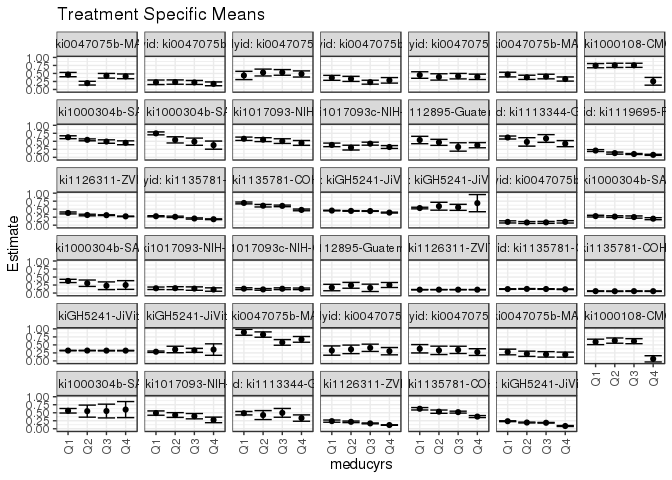

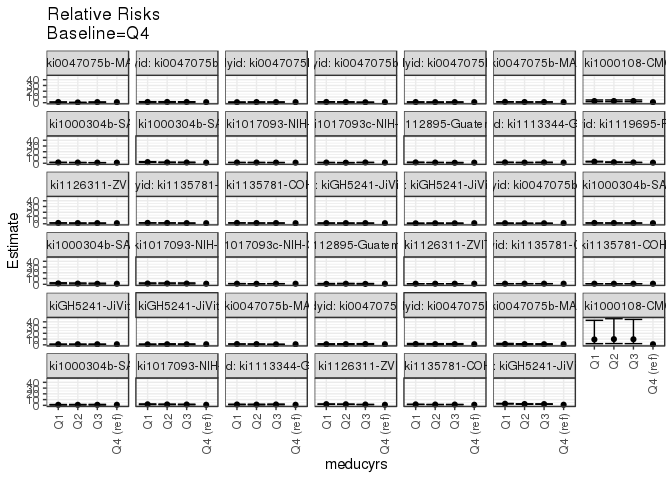

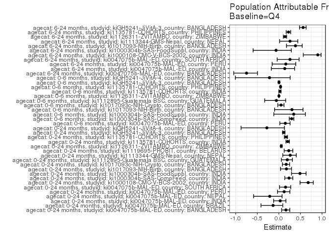

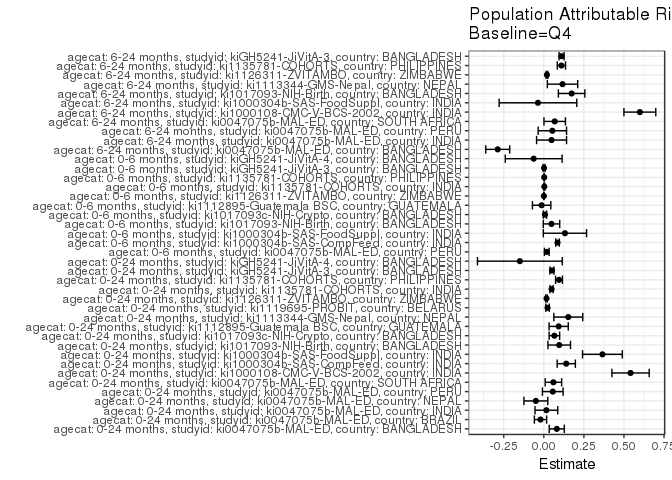

## Results Table

### Parameter: TSM

| agecat | studyid | country | intervention_level | baseline_level | estimate | ci_lower | ci_upper |
| --- | --- | --- | --- | --- | --- | --- | --- |
| 0-24 months | ki0047075b-MAL-ED | BANGLADESH | Q4 | NA | 0.4097274 | 0.3360533 | 0.4834016 |
| 0-24 months | ki0047075b-MAL-ED | BANGLADESH | Q1 | NA | 0.4645292 | 0.3977332 | 0.5313253 |
| 0-24 months | ki0047075b-MAL-ED | BANGLADESH | Q2 | NA | 0.1971477 | 0.1387629 | 0.2555325 |
| 0-24 months | ki0047075b-MAL-ED | BANGLADESH | Q3 | NA | 0.4280029 | 0.3550376 | 0.5009683 |
| 0-24 months | ki0047075b-MAL-ED | BRAZIL | Q4 | NA | 0.1758390 | 0.1166603 | 0.2350176 |
| 0-24 months | ki0047075b-MAL-ED | BRAZIL | Q1 | NA | 0.2241179 | 0.1537682 | 0.2944676 |
| 0-24 months | ki0047075b-MAL-ED | BRAZIL | Q2 | NA | 0.2305179 | 0.1634246 | 0.2976112 |
| 0-24 months | ki0047075b-MAL-ED | BRAZIL | Q3 | NA | 0.2190002 | 0.1571688 | 0.2808316 |
| 0-24 months | ki0047075b-MAL-ED | INDIA | Q4 | NA | 0.4840338 | 0.3883449 | 0.5797227 |
| 0-24 months | ki0047075b-MAL-ED | INDIA | Q1 | NA | 0.4371942 | 0.3083387 | 0.5660497 |
| 0-24 months | ki0047075b-MAL-ED | INDIA | Q2 | NA | 0.5290477 | 0.4219378 | 0.6361577 |
| 0-24 months | ki0047075b-MAL-ED | INDIA | Q3 | NA | 0.5320859 | 0.4439204 | 0.6202514 |
| 0-24 months | ki0047075b-MAL-ED | NEPAL | Q4 | NA | 0.2851957 | 0.1982381 | 0.3721533 |
| 0-24 months | ki0047075b-MAL-ED | NEPAL | Q1 | NA | 0.3633289 | 0.2864615 | 0.4401964 |
| 0-24 months | ki0047075b-MAL-ED | NEPAL | Q2 | NA | 0.3302408 | 0.2505628 | 0.4099188 |
| 0-24 months | ki0047075b-MAL-ED | NEPAL | Q3 | NA | 0.2270447 | 0.1659503 | 0.2881392 |
| 0-24 months | ki0047075b-MAL-ED | PERU | Q4 | NA | 0.3945101 | 0.3105204 | 0.4784997 |
| 0-24 months | ki0047075b-MAL-ED | PERU | Q1 | NA | 0.4506106 | 0.3486273 | 0.5525939 |
| 0-24 months | ki0047075b-MAL-ED | PERU | Q2 | NA | 0.3912706 | 0.2929805 | 0.4895608 |
| 0-24 months | ki0047075b-MAL-ED | PERU | Q3 | NA | 0.4158458 | 0.3305477 | 0.5011439 |
| 0-24 months | ki0047075b-MAL-ED | SOUTH AFRICA | Q4 | NA | 0.3254794 | 0.2604818 | 0.3904769 |
| 0-24 months | ki0047075b-MAL-ED | SOUTH AFRICA | Q1 | NA | 0.4651749 | 0.3928408 | 0.5375090 |
| 0-24 months | ki0047075b-MAL-ED | SOUTH AFRICA | Q2 | NA | 0.3789190 | 0.3127063 | 0.4451316 |
| 0-24 months | ki0047075b-MAL-ED | SOUTH AFRICA | Q3 | NA | 0.4039146 | 0.3324758 | 0.4753533 |
| 0-24 months | ki1000108-CMC-V-BCS-2002 | INDIA | Q4 | NA | 0.2550865 | 0.1341537 | 0.3760193 |
| 0-24 months | ki1000108-CMC-V-BCS-2002 | INDIA | Q1 | NA | 0.7434948 | 0.6773219 | 0.8096677 |
| 0-24 months | ki1000108-CMC-V-BCS-2002 | INDIA | Q2 | NA | 0.7528105 | 0.6866557 | 0.8189653 |
| 0-24 months | ki1000108-CMC-V-BCS-2002 | INDIA | Q3 | NA | 0.7543379 | 0.6896310 | 0.8190448 |
| 0-24 months | ki1000304b-SAS-CompFeed | INDIA | Q4 | NA | 0.4541784 | 0.3931178 | 0.5152390 |
| 0-24 months | ki1000304b-SAS-CompFeed | INDIA | Q1 | NA | 0.6263449 | 0.5810777 | 0.6716121 |

[output cut: 134 more lines]

### Parameter: E(Y)

| agecat | studyid | country | intervention_level | baseline_level | estimate | ci_lower | ci_upper |
| --- | --- | --- | --- | --- | --- | --- | --- |
| 0-24 months | ki0047075b-MAL-ED | BANGLADESH | NA | NA | 0.4906542 | 0.4235187 | 0.5577897 |
| 0-24 months | ki0047075b-MAL-ED | BRAZIL | NA | NA | 0.1551724 | 0.1084814 | 0.2018634 |
| 0-24 months | ki0047075b-MAL-ED | INDIA | NA | NA | 0.5000000 | 0.4337790 | 0.5662210 |
| 0-24 months | ki0047075b-MAL-ED | NEPAL | NA | NA | 0.2355556 | 0.1799851 | 0.2911260 |
| 0-24 months | ki0047075b-MAL-ED | PERU | NA | NA | 0.4503311 | 0.3941253 | 0.5065370 |
| 0-24 months | ki0047075b-MAL-ED | SOUTH AFRICA | NA | NA | 0.3853503 | 0.3314343 | 0.4392663 |
| 0-24 months | ki1000108-CMC-V-BCS-2002 | INDIA | NA | NA | 0.7962466 | 0.7553156 | 0.8371777 |
| 0-24 months | ki1000304b-SAS-CompFeed | INDIA | NA | NA | 0.5942596 | 0.5539147 | 0.6346046 |
| 0-24 months | ki1000304b-SAS-FoodSuppl | INDIA | NA | NA | 0.7464115 | 0.7046540 | 0.7881689 |
| 0-24 months | ki1017093-NIH-Birth | BANGLADESH | NA | NA | 0.5453100 | 0.5063654 | 0.5842547 |
| 0-24 months | ki1017093c-NIH-Crypto | BANGLADESH | NA | NA | 0.3878628 | 0.3531521 | 0.4225735 |
| 0-24 months | ki1112895-Guatemala BSC | GUATEMALA | NA | NA | 0.4716312 | 0.4132646 | 0.5299979 |
| 0-24 months | ki1113344-GMS-Nepal | NEPAL | NA | NA | 0.5792988 | 0.5397316 | 0.6188661 |
| 0-24 months | ki1119695-PROBIT | BELARUS | NA | NA | 0.1006096 | 0.0848963 | 0.1163228 |
| 0-24 months | ki1126311-ZVITAMBO | ZIMBABWE | NA | NA | 0.2928200 | 0.2852961 | 0.3003440 |
| 0-24 months | ki1135781-COHORTS | INDIA | NA | NA | 0.2344498 | 0.2235944 | 0.2453051 |
| 0-24 months | ki1135781-COHORTS | PHILIPPINES | NA | NA | 0.5716154 | 0.5540738 | 0.5891570 |
| 0-24 months | kiGH5241-JiVitA-3 | BANGLADESH | NA | NA | 0.4437909 | 0.4362664 | 0.4513154 |
| 0-24 months | kiGH5241-JiVitA-4 | BANGLADESH | NA | NA | 0.5383615 | 0.5136968 | 0.5630262 |
| 0-6 months | ki0047075b-MAL-ED | PERU | NA | NA | 0.1225166 | 0.0854756 | 0.1595575 |
| 0-6 months | ki1000304b-SAS-CompFeed | INDIA | NA | NA | 0.2882353 | 0.2618269 | 0.3146436 |
| 0-6 months | ki1000304b-SAS-FoodSuppl | INDIA | NA | NA | 0.3822115 | 0.3354600 | 0.4289631 |
| 0-6 months | ki1017093-NIH-Birth | BANGLADESH | NA | NA | 0.1573927 | 0.1289105 | 0.1858749 |
| 0-6 months | ki1017093c-NIH-Crypto | BANGLADESH | NA | NA | 0.1385224 | 0.1139141 | 0.1631308 |
| 0-6 months | ki1112895-Guatemala BSC | GUATEMALA | NA | NA | 0.2377358 | 0.1863852 | 0.2890865 |
| 0-6 months | ki1126311-ZVITAMBO | ZIMBABWE | NA | NA | 0.1054095 | 0.1003282 | 0.1104907 |
| 0-6 months | ki1135781-COHORTS | INDIA | NA | NA | 0.1209820 | 0.1124870 | 0.1294769 |
| 0-6 months | ki1135781-COHORTS | PHILIPPINES | NA | NA | 0.0614781 | 0.0529631 | 0.0699931 |
| 0-6 months | kiGH5241-JiVitA-3 | BANGLADESH | NA | NA | 0.3219708 | 0.3152108 | 0.3287309 |
| 0-6 months | kiGH5241-JiVitA-4 | BANGLADESH | NA | NA | 0.2908422 | 0.2689870 | 0.3126973 |
| 6-24 months | ki0047075b-MAL-ED | BANGLADESH | NA | NA | 0.3841463 | 0.3094772 | 0.4588155 |
| 6-24 months | ki0047075b-MAL-ED | INDIA | NA | NA | 0.3522727 | 0.2815002 | 0.4230452 |
| 6-24 months | ki0047075b-MAL-ED | PERU | NA | NA | 0.3289474 | 0.2678283 | 0.3900664 |
| 6-24 months | ki0047075b-MAL-ED | SOUTH AFRICA | NA | NA | 0.2633929 | 0.2055812 | 0.3212045 |
| 6-24 months | ki1000108-CMC-V-BCS-2002 | INDIA | NA | NA | 0.6631944 | 0.6085159 | 0.7178730 |
| 6-24 months | ki1000304b-SAS-FoodSuppl | INDIA | NA | NA | 0.5619469 | 0.4971181 | 0.6267757 |
| 6-24 months | ki1017093-NIH-Birth | BANGLADESH | NA | NA | 0.4500000 | 0.4023647 | 0.4976353 |
| 6-24 months | ki1113344-GMS-Nepal | NEPAL | NA | NA | 0.4507338 | 0.4060349 | 0.4954326 |
| 6-24 months | ki1126311-ZVITAMBO | ZIMBABWE | NA | NA | 0.1358848 | 0.1289208 | 0.1428487 |
| 6-24 months | ki1135781-COHORTS | PHILIPPINES | NA | NA | 0.4901079 | 0.4693271 | 0.5108888 |
| 6-24 months | kiGH5241-JiVitA-3 | BANGLADESH | NA | NA | 0.1969150 | 0.1888641 | 0.2049658 |

### Parameter: RR

| agecat | studyid | country | intervention_level | baseline_level | estimate | ci_lower | ci_upper |
| --- | --- | --- | --- | --- | --- | --- | --- |
| 0-24 months | ki0047075b-MAL-ED | BANGLADESH | Q4 | Q4 | 1.0000000 | 1.0000000 | 1.0000000 |
| 0-24 months | ki0047075b-MAL-ED | BANGLADESH | Q1 | Q4 | 1.1337519 | 0.9567147 | 1.3435492 |
| 0-24 months | ki0047075b-MAL-ED | BANGLADESH | Q2 | Q4 | 0.4811679 | 0.3609630 | 0.6414025 |
| 0-24 months | ki0047075b-MAL-ED | BANGLADESH | Q3 | Q4 | 1.0446040 | 0.8714906 | 1.2521049 |
| 0-24 months | ki0047075b-MAL-ED | BRAZIL | Q4 | Q4 | 1.0000000 | 1.0000000 | 1.0000000 |
| 0-24 months | ki0047075b-MAL-ED | BRAZIL | Q1 | Q4 | 1.2745634 | 0.8690261 | 1.8693476 |
| 0-24 months | ki0047075b-MAL-ED | BRAZIL | Q2 | Q4 | 1.3109603 | 0.9145155 | 1.8792648 |
| 0-24 months | ki0047075b-MAL-ED | BRAZIL | Q3 | Q4 | 1.2454588 | 0.8737654 | 1.7752680 |
| 0-24 months | ki0047075b-MAL-ED | INDIA | Q4 | Q4 | 1.0000000 | 1.0000000 | 1.0000000 |
| 0-24 months | ki0047075b-MAL-ED | INDIA | Q1 | Q4 | 0.9032307 | 0.6525204 | 1.2502686 |
| 0-24 months | ki0047075b-MAL-ED | INDIA | Q2 | Q4 | 1.0929975 | 0.8480072 | 1.4087658 |
| 0-24 months | ki0047075b-MAL-ED | INDIA | Q3 | Q4 | 1.0992743 | 0.8814493 | 1.3709284 |
| 0-24 months | ki0047075b-MAL-ED | NEPAL | Q4 | Q4 | 1.0000000 | 1.0000000 | 1.0000000 |
| 0-24 months | ki0047075b-MAL-ED | NEPAL | Q1 | Q4 | 1.2739636 | 0.9271269 | 1.7505514 |
| 0-24 months | ki0047075b-MAL-ED | NEPAL | Q2 | Q4 | 1.1579445 | 0.8266249 | 1.6220605 |
| 0-24 months | ki0047075b-MAL-ED | NEPAL | Q3 | Q4 | 0.7961015 | 0.5704838 | 1.1109476 |
| 0-24 months | ki0047075b-MAL-ED | PERU | Q4 | Q4 | 1.0000000 | 1.0000000 | 1.0000000 |
| 0-24 months | ki0047075b-MAL-ED | PERU | Q1 | Q4 | 1.1422031 | 0.8555858 | 1.5248358 |
| 0-24 months | ki0047075b-MAL-ED | PERU | Q2 | Q4 | 0.9917887 | 0.7301410 | 1.3471985 |
| 0-24 months | ki0047075b-MAL-ED | PERU | Q3 | Q4 | 1.0540816 | 0.8067266 | 1.3772795 |
| 0-24 months | ki0047075b-MAL-ED | SOUTH AFRICA | Q4 | Q4 | 1.0000000 | 1.0000000 | 1.0000000 |
| 0-24 months | ki0047075b-MAL-ED | SOUTH AFRICA | Q1 | Q4 | 1.4291994 | 1.1367550 | 1.7968787 |
| 0-24 months | ki0047075b-MAL-ED | SOUTH AFRICA | Q2 | Q4 | 1.1641874 | 0.9227492 | 1.4687982 |
| 0-24 months | ki0047075b-MAL-ED | SOUTH AFRICA | Q3 | Q4 | 1.2409836 | 0.9782378 | 1.5743007 |
| 0-24 months | ki1000108-CMC-V-BCS-2002 | INDIA | Q4 | Q4 | 1.0000000 | 1.0000000 | 1.0000000 |
| 0-24 months | ki1000108-CMC-V-BCS-2002 | INDIA | Q1 | Q4 | 2.9146773 | 1.8039691 | 4.7092511 |
| 0-24 months | ki1000108-CMC-V-BCS-2002 | INDIA | Q2 | Q4 | 2.9511971 | 1.8272144 | 4.7665805 |
| 0-24 months | ki1000108-CMC-V-BCS-2002 | INDIA | Q3 | Q4 | 2.9571850 | 1.8311299 | 4.7757090 |
| 0-24 months | ki1000304b-SAS-CompFeed | INDIA | Q4 | Q4 | 1.0000000 | 1.0000000 | 1.0000000 |
| 0-24 months | ki1000304b-SAS-CompFeed | INDIA | Q1 | Q4 | 1.3790724 | 1.2069834 | 1.5756976 |

[output cut: 134 more lines]

### Parameter: PAR

| agecat | studyid | country | intervention_level | baseline_level | estimate | ci_lower | ci_upper |
| --- | --- | --- | --- | --- | --- | --- | --- |
| 0-24 months | ki0047075b-MAL-ED | BANGLADESH | Q4 | NA | 0.0809268 | 0.0338635 | 0.1279900 |
| 0-24 months | ki0047075b-MAL-ED | BRAZIL | Q4 | NA | -0.0206666 | -0.0588036 | 0.0174705 |
| 0-24 months | ki0047075b-MAL-ED | INDIA | Q4 | NA | 0.0159662 | -0.0550279 | 0.0869603 |
| 0-24 months | ki0047075b-MAL-ED | NEPAL | Q4 | NA | -0.0496401 | -0.1240870 | 0.0248067 |
| 0-24 months | ki0047075b-MAL-ED | PERU | Q4 | NA | 0.0558211 | -0.0087362 | 0.1203783 |
| 0-24 months | ki0047075b-MAL-ED | SOUTH AFRICA | Q4 | NA | 0.0598710 | 0.0085416 | 0.1112003 |
| 0-24 months | ki1000108-CMC-V-BCS-2002 | INDIA | Q4 | NA | 0.5411602 | 0.4247758 | 0.6575445 |
| 0-24 months | ki1000304b-SAS-CompFeed | INDIA | Q4 | NA | 0.1400812 | 0.0832752 | 0.1968872 |
| 0-24 months | ki1000304b-SAS-FoodSuppl | INDIA | Q4 | NA | 0.3657316 | 0.2416060 | 0.4898572 |
| 0-24 months | ki1017093-NIH-Birth | BANGLADESH | Q4 | NA | 0.0961503 | 0.0257270 | 0.1665735 |
| 0-24 months | ki1017093c-NIH-Crypto | BANGLADESH | Q4 | NA | 0.0659926 | 0.0332409 | 0.0987444 |
| 0-24 months | ki1112895-Guatemala BSC | GUATEMALA | Q4 | NA | 0.0925775 | 0.0326058 | 0.1525492 |
| 0-24 months | ki1113344-GMS-Nepal | NEPAL | Q4 | NA | 0.1527463 | 0.0625338 | 0.2429588 |
| 0-24 months | ki1119695-PROBIT | BELARUS | Q4 | NA | 0.0231663 | 0.0125737 | 0.0337588 |
| 0-24 months | ki1126311-ZVITAMBO | ZIMBABWE | Q4 | NA | 0.0168811 | 0.0122064 | 0.0215559 |
| 0-24 months | ki1135781-COHORTS | INDIA | Q4 | NA | 0.0484399 | 0.0385992 | 0.0582805 |
| 0-24 months | ki1135781-COHORTS | PHILIPPINES | Q4 | NA | 0.0947234 | 0.0733389 | 0.1161080 |
| 0-24 months | kiGH5241-JiVitA-3 | BANGLADESH | Q4 | NA | 0.0506963 | 0.0380217 | 0.0633709 |
| 0-24 months | kiGH5241-JiVitA-4 | BANGLADESH | Q4 | NA | -0.1495071 | -0.4140809 | 0.1150668 |
| 0-6 months | ki0047075b-MAL-ED | PERU | Q4 | NA | 0.0183648 | 0.0037045 | 0.0330250 |
| 0-6 months | ki1000304b-SAS-CompFeed | INDIA | Q4 | NA | 0.0855034 | 0.0741951 | 0.0968118 |
| 0-6 months | ki1000304b-SAS-FoodSuppl | INDIA | Q4 | NA | 0.1317458 | -0.0031294 | 0.2666210 |
| 0-6 months | ki1017093-NIH-Birth | BANGLADESH | Q4 | NA | 0.0479389 | -0.0032760 | 0.0991538 |
| 0-6 months | ki1017093c-NIH-Crypto | BANGLADESH | Q4 | NA | 0.0069950 | -0.0030932 | 0.0170831 |
| 0-6 months | ki1112895-Guatemala BSC | GUATEMALA | Q4 | NA | -0.0135781 | -0.0709707 | 0.0438144 |
| 0-6 months | ki1126311-ZVITAMBO | ZIMBABWE | Q4 | NA | 0.0002260 | -0.0002155 | 0.0006676 |
| 0-6 months | ki1135781-COHORTS | INDIA | Q4 | NA | 0.0030716 | 0.0000270 | 0.0061162 |
| 0-6 months | ki1135781-COHORTS | PHILIPPINES | Q4 | NA | 0.0024719 | 0.0016544 | 0.0032893 |
| 0-6 months | kiGH5241-JiVitA-3 | BANGLADESH | Q4 | NA | 0.0012713 | -0.0041899 | 0.0067325 |
| 0-6 months | kiGH5241-JiVitA-4 | BANGLADESH | Q4 | NA | -0.0631750 | -0.2404486 | 0.1140985 |
| 6-24 months | ki0047075b-MAL-ED | BANGLADESH | Q4 | NA | -0.2875518 | -0.3622890 | -0.2128146 |
| 6-24 months | ki0047075b-MAL-ED | INDIA | Q4 | NA | 0.0483507 | -0.0451790 | 0.1418804 |
| 6-24 months | ki0047075b-MAL-ED | PERU | Q4 | NA | 0.0532727 | -0.0353617 | 0.1419072 |
| 6-24 months | ki0047075b-MAL-ED | SOUTH AFRICA | Q4 | NA | 0.0679788 | 0.0009352 | 0.1350224 |
| 6-24 months | ki1000108-CMC-V-BCS-2002 | INDIA | Q4 | NA | 0.5991910 | 0.4998120 | 0.6985699 |
| 6-24 months | ki1000304b-SAS-FoodSuppl | INDIA | Q4 | NA | -0.0365697 | -0.2787507 | 0.2056114 |
| 6-24 months | ki1017093-NIH-Birth | BANGLADESH | Q4 | NA | 0.1734982 | 0.0909033 | 0.2560930 |
| 6-24 months | ki1113344-GMS-Nepal | NEPAL | Q4 | NA | 0.1167327 | 0.0219528 | 0.2115125 |
| 6-24 months | ki1126311-ZVITAMBO | ZIMBABWE | Q4 | NA | 0.0195263 | 0.0141960 | 0.0248567 |
| 6-24 months | ki1135781-COHORTS | PHILIPPINES | Q4 | NA | 0.1097525 | 0.0839931 | 0.1355119 |
| 6-24 months | kiGH5241-JiVitA-3 | BANGLADESH | Q4 | NA | 0.1107893 | 0.0949559 | 0.1266227 |

### Parameter: PAF

| agecat | studyid | country | intervention_level | baseline_level | estimate | ci_lower | ci_upper |
| --- | --- | --- | --- | --- | --- | --- | --- |
| 0-24 months | ki0047075b-MAL-ED | BANGLADESH | Q4 | NA | 0.1649365 | 0.0655182 | 0.2537778 |
| 0-24 months | ki0047075b-MAL-ED | BRAZIL | Q4 | NA | -0.1331844 | -0.4135097 | 0.0915471 |
| 0-24 months | ki0047075b-MAL-ED | INDIA | Q4 | NA | 0.0319324 | -0.1209296 | 0.1639486 |
| 0-24 months | ki0047075b-MAL-ED | NEPAL | Q4 | NA | -0.2107364 | -0.5851280 | 0.0752276 |
| 0-24 months | ki0047075b-MAL-ED | PERU | Q4 | NA | 0.1239556 | -0.0320944 | 0.2564113 |
| 0-24 months | ki0047075b-MAL-ED | SOUTH AFRICA | Q4 | NA | 0.1553676 | 0.0151110 | 0.2756505 |
| 0-24 months | ki1000108-CMC-V-BCS-2002 | INDIA | Q4 | NA | 0.6796389 | 0.4912922 | 0.7982510 |
| 0-24 months | ki1000304b-SAS-CompFeed | INDIA | Q4 | NA | 0.2357240 | 0.1368713 | 0.3232552 |
| 0-24 months | ki1000304b-SAS-FoodSuppl | INDIA | Q4 | NA | 0.4899866 | 0.2943142 | 0.6314030 |
| 0-24 months | ki1017093-NIH-Birth | BANGLADESH | Q4 | NA | 0.1763222 | 0.0381876 | 0.2946180 |
| 0-24 months | ki1017093c-NIH-Crypto | BANGLADESH | Q4 | NA | 0.1701443 | 0.0821587 | 0.2496955 |
| 0-24 months | ki1112895-Guatemala BSC | GUATEMALA | Q4 | NA | 0.1962922 | 0.0577265 | 0.3144811 |
| 0-24 months | ki1113344-GMS-Nepal | NEPAL | Q4 | NA | 0.2636744 | 0.0909434 | 0.4035846 |
| 0-24 months | ki1119695-PROBIT | BELARUS | Q4 | NA | 0.2302589 | 0.1241433 | 0.3235180 |
| 0-24 months | ki1126311-ZVITAMBO | ZIMBABWE | Q4 | NA | 0.0576502 | 0.0416300 | 0.0734026 |
| 0-24 months | ki1135781-COHORTS | INDIA | Q4 | NA | 0.2066108 | 0.1650057 | 0.2461429 |
| 0-24 months | ki1135781-COHORTS | PHILIPPINES | Q4 | NA | 0.1657118 | 0.1274982 | 0.2022518 |
| 0-24 months | kiGH5241-JiVitA-3 | BANGLADESH | Q4 | NA | 0.1142347 | 0.0853573 | 0.1422004 |
| 0-24 months | kiGH5241-JiVitA-4 | BANGLADESH | Q4 | NA | -0.2777076 | -0.8753710 | 0.1294861 |
| 0-6 months | ki0047075b-MAL-ED | PERU | Q4 | NA | 0.1498962 | 0.0227345 | 0.2605116 |
| 0-6 months | ki1000304b-SAS-CompFeed | INDIA | Q4 | NA | 0.2966445 | 0.2411009 | 0.3481229 |
| 0-6 months | ki1000304b-SAS-FoodSuppl | INDIA | Q4 | NA | 0.3446934 | -0.1158520 | 0.6151580 |
| 0-6 months | ki1017093-NIH-Birth | BANGLADESH | Q4 | NA | 0.3045816 | -0.0991899 | 0.5600335 |
| 0-6 months | ki1017093c-NIH-Crypto | BANGLADESH | Q4 | NA | 0.0504970 | -0.0242634 | 0.1198006 |
| 0-6 months | ki1112895-Guatemala BSC | GUATEMALA | Q4 | NA | -0.0571144 | -0.3284962 | 0.1588302 |
| 0-6 months | ki1126311-ZVITAMBO | ZIMBABWE | Q4 | NA | 0.0021443 | -0.0020509 | 0.0063220 |
| 0-6 months | ki1135781-COHORTS | INDIA | Q4 | NA | 0.0253890 | 0.0000218 | 0.0501127 |
| 0-6 months | ki1135781-COHORTS | PHILIPPINES | Q4 | NA | 0.0402075 | 0.0279720 | 0.0522889 |
| 0-6 months | kiGH5241-JiVitA-3 | BANGLADESH | Q4 | NA | 0.0039484 | -0.0131519 | 0.0207601 |
| 0-6 months | kiGH5241-JiVitA-4 | BANGLADESH | Q4 | NA | -0.2172141 | -1.0086673 | 0.2623914 |
| 6-24 months | ki0047075b-MAL-ED | BANGLADESH | Q4 | NA | -0.7485475 | -1.0450452 | -0.4950371 |
| 6-24 months | ki0047075b-MAL-ED | INDIA | Q4 | NA | 0.1372536 | -0.1733316 | 0.3656258 |
| 6-24 months | ki0047075b-MAL-ED | PERU | Q4 | NA | 0.1619491 | -0.1553331 | 0.3920981 |
| 6-24 months | ki0047075b-MAL-ED | SOUTH AFRICA | Q4 | NA | 0.2580890 | -0.0379501 | 0.4696932 |
| 6-24 months | ki1000108-CMC-V-BCS-2002 | INDIA | Q4 | NA | 0.9034922 | 0.5663659 | 0.9785216 |
| 6-24 months | ki1000304b-SAS-FoodSuppl | INDIA | Q4 | NA | -0.0650767 | -0.5965055 | 0.2894554 |
| 6-24 months | ki1017093-NIH-Birth | BANGLADESH | Q4 | NA | 0.3855515 | 0.1766960 | 0.5414246 |
| 6-24 months | ki1113344-GMS-Nepal | NEPAL | Q4 | NA | 0.2589836 | 0.0184204 | 0.4405902 |
| 6-24 months | ki1126311-ZVITAMBO | ZIMBABWE | Q4 | NA | 0.1436979 | 0.1045842 | 0.1811029 |
| 6-24 months | ki1135781-COHORTS | PHILIPPINES | Q4 | NA | 0.2239353 | 0.1698677 | 0.2744814 |
| 6-24 months | kiGH5241-JiVitA-3 | BANGLADESH | Q4 | NA | 0.5626249 | 0.4788599 | 0.6329259 |